# Lecture #6: Typora & LaTeX

Nicholas J. Gotelli

January 30 2020

### Three ways to use R

- from console (in R studio and in shell)
- from .Rmd markdown file (markdown)
- from .R script file

#### General Rstudio shortcuts

```
control 1 : move to script panel
control 2 : move to console panel
control shift 1 : move to script panel and expand
control shift 2 : move to console panel and expand
control l : to clear the console
```

#### Working with Rmarkdown

- render to view pane not to browser
- set up headers in YAML
- keep first chunk in place
- set options in chunks for `echo, eval`

#### Rmarkdown shortcuts

```
CTRL-SHIFT-k : knits the markdown file to html/pdf/word
CTRL-OPTION-i : inserts a new R chunk
```

#### Fencing

- for plain text (show a sample)
- chunk for R code (show a few lines)
- even a chunk for bash (show pwd command)

#### Three languages in one file!

- rmarkdown (for text, links, images)
- r code (for computing)
- LaTeX for rendering math equations

#### All three in one sentence:

The value of $\pi$ is 3.1415927.

### Equations

- in-line `$`
- centered `$$`
- basic math and text spacing handled by LateX

```
$$y = a + b$$
```

$$y = a + b$$

#### Subcripts

```
$$H_0 = Z_{a + b}$$
```

$$H_0 = Z_{a + b}$$

####Superscripts

```
$$S = cA^z$$
```

$$S = cA^z$$

- elements can be coupled and nested

$$S=cA^z_1 + z_{2 + x}$$

```
$$S=cA^z_1 + z_{2 + x}$$
```

#### Fractions and Greek Symbols

$$\alpha = \frac{\beta}{\delta + \gamma_x}$$

```
$$\alpha = \frac{\beta}{\delta + \gamma_x}$$
```

#### Summation signs

$$z = \sum_{i=1}^X{K}$$

```
$$z = \sum_{i=1}^X{K}$$
```

#### “Escaping” the special character in LaTeX

Use `\backslash`

```
$$\backslash \alpha \le b \backslash$$
```

$$\backslash \alpha \le b \backslash$$

#### Rendering plain text in a LaTex Equation

$$P(Occurrence Of Species A) = Z$$

```
$$P(Occurrence Of Species A) = Z$$
```

$$P(\mbox{Occurrence Of Species A}) = Z$$

```
$$P(\mbox{Occurrence Of Species A}) = Z$$
```

### R Code in Chunks

- `CTRL-ALT-I` inserts a new “chunk” of R code

```r
# Use comments extensively in ALL of your coding!
Pred <- seq(1,10)     # make a vector of integers from 1 to 10
Res <- runif(10)      # generate 10 draws from a random uniform (0,1) distribution

# print the random numbers
print(Res)
```

```
##  [1] 0.7036237 0.9049534 0.3637800 0.6950241
##  [5] 0.6091506 0.7066348 0.4177027 0.5760206
##  [9] 0.1045000 0.9589520
```

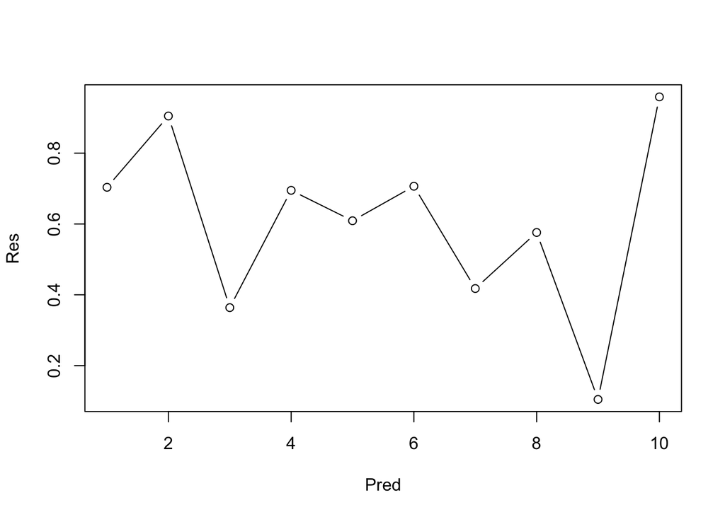

```r
# plot the graph
plot(x=Pred,y=Res,type="b")
```

### Using chunk options to control printing of code and output

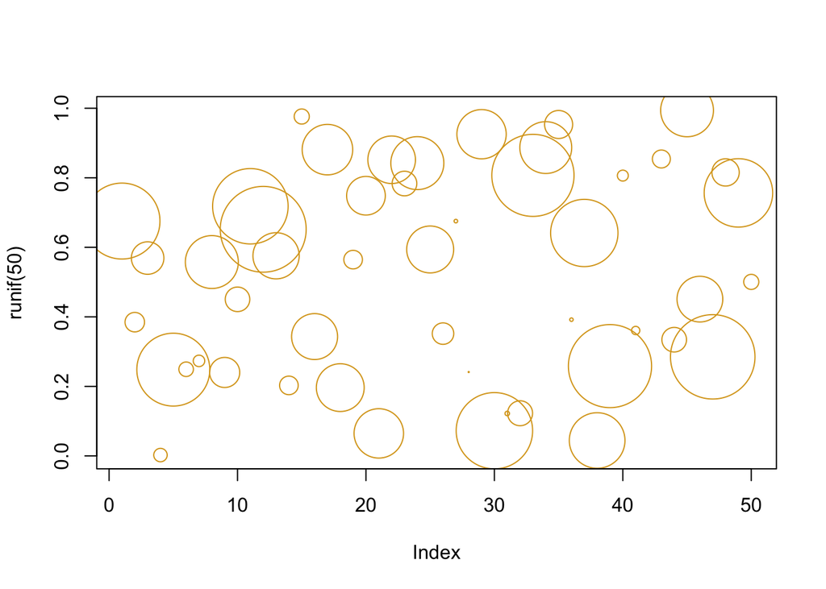

```r
plot(runif(50),cex=10*runif(50),col="goldenrod")
```

```r
print(rnorm(n=10, mean=10, sd=2))
```

```
##  [1]  9.392622  8.975987  8.726220  9.787122
##  [5] 10.355045 12.141175 11.931862  8.648462
##  [9] 12.949979  9.249473
```

### Writing R scripts

- new script
- code executes and prints in console
- graphs in output window
- `CTRL - ENTER` to run a single line of code
- `CTRL - SHIFT - ENTER` to source the entire script
- code to illustrate:

```r
# First comment to explain what this program is doing.
# Be expansive and describe it in great detail. This may seem trivial, but will become increasingly important as you create complex programs.
# Simple script to examine the distribution of the product of two uniform variables
# Make sure it is readable. Use complete sentences, not cryptic phrases.
# 6 September 2018
# NJG

# Preliminaries
library(ggplot2)
set.seed(100)
library(TeachingDemos) # use this to set the random number seed from a character string
char2seed("green tea")
char2seed("green tea",set=FALSE)
```

```
## [1] 7023541
```

```r
#

# Global variables
nRep <- 10000

# Create or read in data
ranVar1 <- rnorm(nRep)
# print(ranVar1)
head(ranVar1)
```

```
## [1] -0.67595800  0.07142749 -0.13803318
## [4] -0.99300667 -1.17181879  0.51340840
```

```r
tail(ranVar1)
```

```
## [1]  0.35209291 -0.11819204  0.57509922
## [4] -0.05122504 -1.98879289 -1.04776740
```

[output not shown]

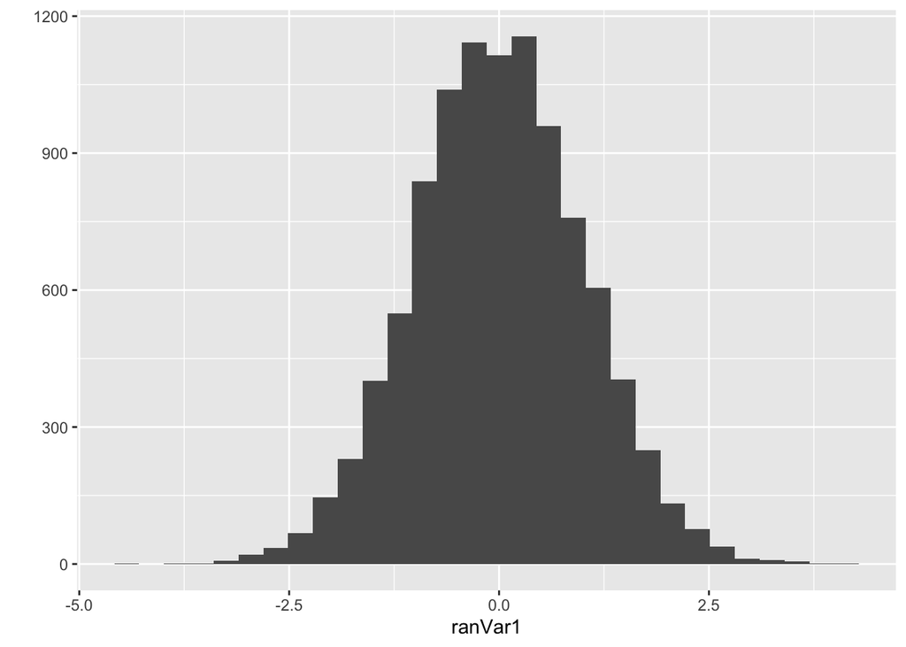

```r
ranVar2 <- rnorm(nRep)


# visualize data
qplot(x=ranVar1)
```

[output not shown]

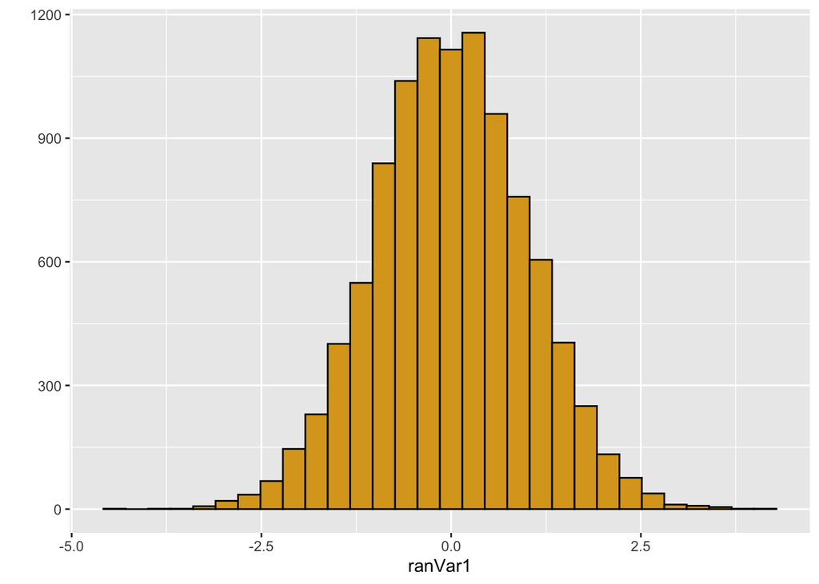

```r
qplot(x=ranVar1,color=I("black"),fill=I("goldenrod"))
```

[output not shown]

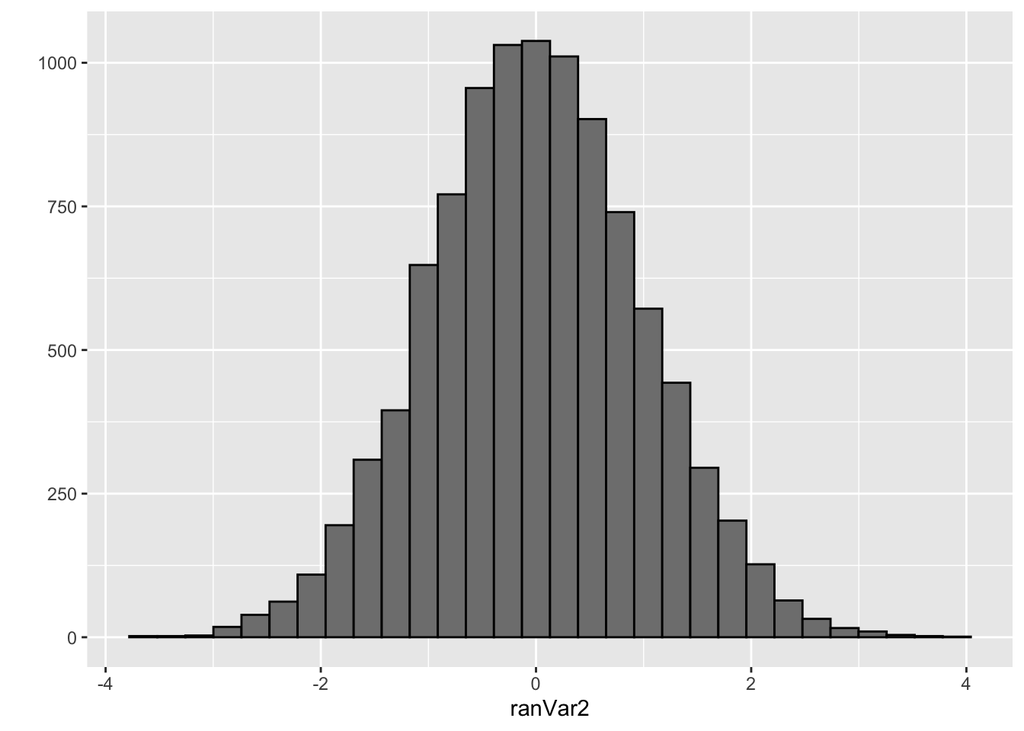

```r
qplot(x=ranVar2,color=I("black"),fill=I("grey50"))
```

```r
# create product vector
ranProd <- ranVar1*ranVar2
length(ranProd)
```

```
## [1] 10000
```

```r
str(ranProd)
```

```
##  num [1:10000] -1.3151 0.0117 0.1435 2.2531 -0.9411 ...
```

```r
head(ranProd)
```

```
## [1] -1.31510790  0.01168855  0.14346105
## [4]  2.25309300 -0.94114160  0.13995337
```

[output not shown]

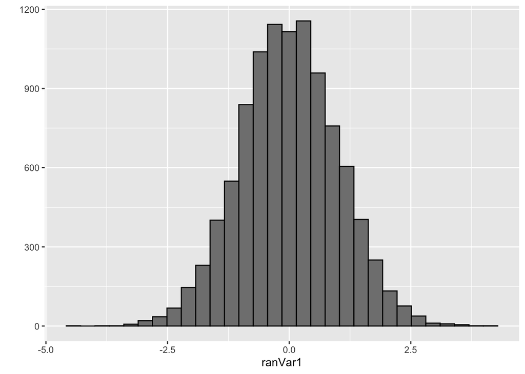

```r
# visualize product vector
qplot(x=ranVar1,color=I("black"),fill=I(grey(0.5)))
```

```r
# do other stuff..
```

### Converting `.R` files to `.html` (creating an R notebook)

- use notebook script
- roxygen comments ``#`

### `Purling` to strip and consolidate R chunks from a Markdown file

- commands executed from console

```
library(knitr)
purl("FileName.Rmd")
```

These commands will create a file `FileName.R` that has all of the R code and none of the markdown text. R comments are still retained.

### Bonus: A Cool New Markdown Editor!

- Demo of `Typora` a WYSIWYG text editor at https://typora.io/